# Chapter 4 Create heat maps

## 4.1 Description

I’m curious where the cows are hanging out, and if there is much difference between the areas inhabited by angus vs criollo cows. Before doing any advanced analyses, my first step will be to plot the points from the cows’ GPS collars, overlaid on maps of the pastures in Indian Creek.

## 4.2 Load in pasture shapefiles

```r
cottonwood = read_sf("./../spatial data/Cottonwood_Allotment_and_pasture_boundaries/Cottonwood_Allotment_and_pasture_boundaries.shp")

indianCreek = read_sf("./../spatial data/Cottonwood_Allotment_and_pasture_boundaries/BLM_IndianCreekAllotment.shp")

winterUSU = read_sf("./../spatial data/USU_study_winter_pastures_dissolve/USU_study_winter_pastures_dissolve.shp")
```

## 4.3 Read in collar data, reproject to UTM, and convert to sf object

Here I’ll read in the .csv file I created in Chapter 2 that contains all the GPS collar data combined and organized.

```r
# read in data
cattle.dat = read.csv('../cattle/processed data/2021-2022_GPS-combined.csv')

# convert to sf object
cattle.gps = st_as_sf(cattle.dat, coords = c('Longitude', 'Latitude'))
st_crs(cattle.gps) = CRS("+proj=longlat +ellps=WGS84")

# reproject to UTM
cattle.gps$geometry = st_transform(cattle.gps$geometry,
                         crs = st_crs(cottonwood))

st_crs(cattle.gps) == st_crs(indianCreek)
```

```
## [1] TRUE
```

```r
# convert dates to posixct
cattle.gps$date_time = as.POSIXct(cattle.gps$date_time)

# convert breed to factor
cattle.gps$breed = as.factor(cattle.gps$breed)
```

## 4.4 Calculate activity modes

Before I make the heatmaps, I’d like to classify the data by activity mode (namely, resting or grazing) based on the movement velocity recorded by the collars. That way, I can see if there there are differences within and between breeds in the areas used for grazing or resting. I don’t care quite so much right now about the areas the cows just travel through, I really just want to know where they’re hanging out.

```r
# create and clean cattle.frame
cattle.frame = (cattle.gps) %>%
  filter(!is.na(breed) &
           !is.na(date_time)) %>%
  mutate(tag.no = as.factor(tag.no)) %>%
  distinct()

# add x and y coordinates
cattle.frame =  bind_cols(cattle.frame,
                          as.data.frame(st_coordinates(cattle.frame)))

cattle.list = split(cattle.frame, f = cattle.frame$tag.no)

# make track
cattle.track = lapply(cattle.list,
                      FUN = mk_track, .x = X, .y = Y, .t = date_time,
                      crs = st_crs(cattle.gps),
                      order_by_ts = T,
                      check_duplicates = F)
rm(cattle.list)

# calculate velocity from track
tags = levels(cattle.frame$tag.no)
cattle.speed = lapply(cattle.track, FUN = speed)
for(i in seq(1:length(tags))){
  c = tags[i]
  cattle.track[[c]][4] = cattle.speed[[c]]
  names(cattle.track[[c]])[4] = 'speed'
}

# convert list back into data.frame
speed.frame = list.rbind(cattle.track)
temp = array()
for(i in seq(1:length(tags))){
  temp = append(temp, rep(tags[i], times = dim(cattle.track[[i]])[1]))
}
temp = temp[!is.na(temp)]

speed.frame = speed.frame %>%
  mutate(tag.no = temp) %>%
  rename(X = x_, Y = y_, date_time = t_)

rm(cattle.track)

# merge cattle.frame and speed.frame
cattle.frame = merge(cattle.frame, speed.frame[,3:5],
                       by = c('tag.no','date_time'))

# classify activity based on speed (from Nyamuryekung'e et al. 2021a)
resting = 2.34/60 # max resting speed in m/s
grazing = 25/60 # max grazing speed in m/s

cattle.frame = cattle.frame %>%
  mutate(activity = case_when(speed <= resting ~  'resting',
                            speed > resting & speed <= grazing ~
                              'grazing',
                            speed > grazing ~  'traveling',
                            T ~ 'none'))

cattle.grazing = cattle.frame %>%
  filter(activity == 'grazing')

cattle.resting = cattle.frame %>%
  filter(activity == 'resting')
```

## 4.5 Create map of pastures

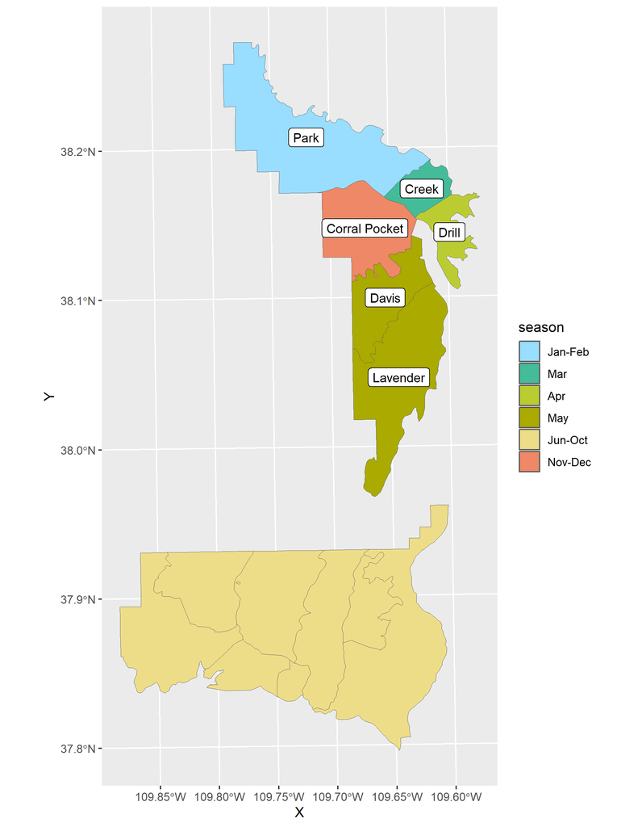

## 4.6 Interactive maps of each pasture

In this section, I have created Leaflet maps of each pasture. Feel free to zoom in and out in each map!

### 4.6.1 Park Pasture

```r
# Activity mode = resting
park.map.resting
```

[interactive chart not shown]

```r
# Activity mode = grazing
park.map.grazing
```

[interactive chart not shown]

### 4.6.2 Creek Pasture

```r
# Activity mode = resting
creek.map.resting
```

[interactive chart not shown]

```r
# Activity mode = grazing
creek.map.grazing
```

[interactive chart not shown]

### 4.6.3 Drill Pasture

```r
# Activity mode = resting
drill.map.resting
```

[interactive chart not shown]

```r
# Activity mode = grazing
drill.map.grazing
```

[interactive chart not shown]

### 4.6.4 Davis and Lavender Canyons

```r
# Activity mode = resting
davis.lav.map.resting
```

[interactive chart not shown]

```r
# Activity mode = grazing
davis.lav.map.grazing
```

[interactive chart not shown]

### 4.6.5 Corral Pocket

```r
# Activity mode = resting
corral.map.resting
```

[interactive chart not shown]

```r
# Activity mode = grazing
corral.map.grazing
```

[interactive chart not shown]